# Calculation of Objective Functions

Daniel Klotz, Johannes Wesemann, Mathew Herrnegger

12 Juli 2016

# 1 Introduction

This chapter explains the code to calculate the main objective functions $of$ used in visCOS. As explained in respective section objective functions are a pivotal part of model calibration. As of now, **visCOS** focuses on 4 main objective function: NSE, KGE, Pearson’s Correlation and the Percentage bias (the respective definitions are given here).

The main objective functions for the overall data and the marked periods can be computed through the function `main_of_compute`. In order to run the function the period have to be marked first, e.g. through the `mark_periods` function. Additionally, **visCOS** already provides two different options to create plots for the main objective functions: `main_of_rasterplot` and `main_of_barplot`. Both functions create a list with 4 `ggplot` figures. Each entry in the list corresponds to one of the main objective functions and both lists can be saved to html embedded .jpgs with the `serve` function.

**Examples:**

Computing the main objective functions

```r
require(visCOS)
require(magrittr)
of_values <- get_cos_data_example() %>%
  mark_periods() %>%
  main_of_compute()
of_values
```

```
##                 of    basin.1     basin.2
## 1              NSE  0.5177309   0.8012919
## 2              KGE  0.7246877   0.7489862
## 3           p_bias  0.3000000 -12.5000000
## 4             CORR  0.8177663   0.9107391
## 5     NSE_period.1  0.1326604   0.7566200
## 6     NSE_period.2  0.7096110   0.8168895
## 7     KGE_period.1  0.4138710   0.8487406
## 8     KGE_period.2  0.8419666   0.6820128
## 9  p_bias_period.1  8.8000000  -8.6000000
## 10 p_bias_period.2 -6.9000000 -15.9000000
## 11   CORR_period.1  0.8243198   0.8806770
## 12   CORR_period.2  0.8577983   0.9385221
```

Plotting the results of main objective function with bar plots:

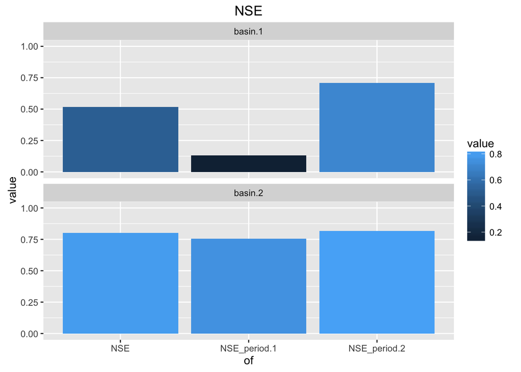

```r
of_values <- get_cos_data_example() %>%
  mark_periods() %>%
  main_of_barplot() %>%
  extract2(1) %>%
  plot()
```

Plotting the results of main objective function with a raster:

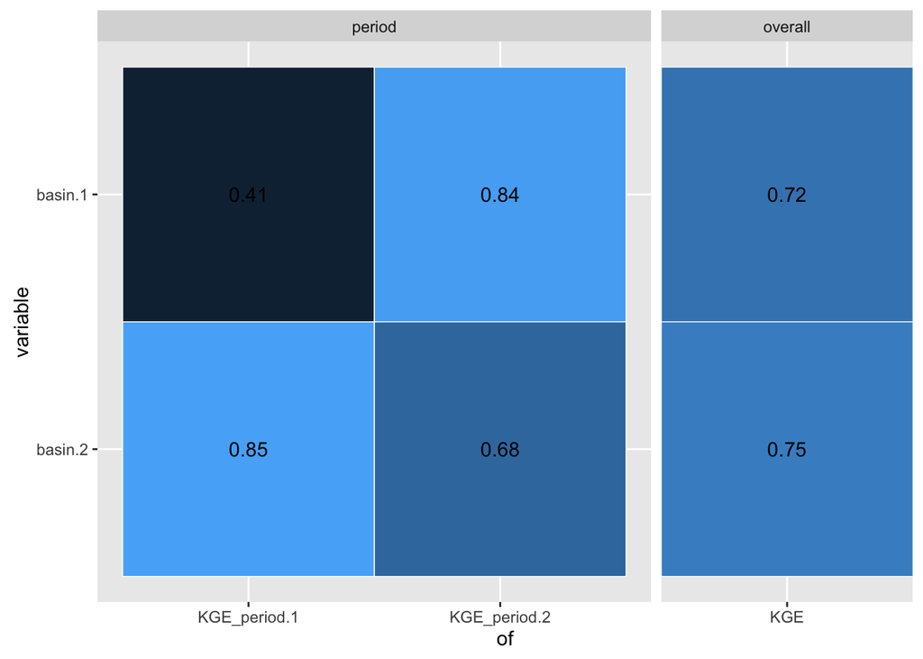

```r
of_values <- get_cos_data_example() %>%
  mark_periods() %>%
  main_of_rasterplot() %>%
  extract2(2) %>%
  plot()
```

# 2 Code

In this section the code for the `main_of` function family is defined

## 2.1 Compute the Main Objective Functions

The purpose of this function is to extract a the main of objective functions from the `COSERO` data.frame. The objective functions are extracted for each basin separately and computed for the entire length of the data, as well as for each period separately.

```r
#' Get basic objective function for cos_data
#'
#' Calculate basic objective functions(NSE, KGE, percentage BIAS, Correlation)
#' for every basin and the chosen periods.
#'
#' @param cos_data cos_data data.frame.
#' @return list of basic objective function evaluated for the different
#' hydrological years and over the whole timespan.
#'
#' @import hydroGOF
#' @import dplyr
#'
#' @export
main_of_compute <- function(cos_data) {
  assert_dataframe(cos_data)
  if( !exists(viscos_options("name_COSperiod"), where = cos_data) ) {
    stop("Error! Period-Column missing in cos_data, use `mark_periods`")
  }
```

The computational part of the function works as follows. In step (I) the non-marked periods of `cos_data` (columns of `viscos_options("name_COSperiod")` which are smaller then 0) are excluded from further calculations. The thereby obtained data.frame is named `evaluation_data`.

```r
  evaluation_data <-
    cos_data[ cos_data[[viscos_options("name_COSperiod")]] > 0, ]
```

Extract the important information for the calculations:

```r
  number_of_basins <- evaluation_data %>%
    names %>%
    unique %>%
    grepl(viscos_options("name_o"), ., ignore.case = TRUE) %>%
    sum
  periods_in_data <- evaluation_data %>%
    magrittr::extract2(viscos_options("name_COSperiod")) %>%
    unique
  number_of_periods <- periods_in_data %>% length
```

Next, compute the overall objective functions. This is done by copying all `viscos_options("name_o")` columns into the `temp_x` variable and all `viscos_options("name_s")` into the `temp_y` variable.

```r
  temp_x <- dplyr::select(evaluation_data,starts_with(viscos_options("name_o"))) %>%
    unname
  temp_y <- dplyr::select(evaluation_data,starts_with(viscos_options("name_s"))) %>%
    unname
  nse_ <- hydroGOF::NSE(temp_y,temp_x)
  kge_ <- hydroGOF::KGE(temp_y,temp_x)
  p_bias_ <- hydroGOF::pbias(temp_y,temp_x)
  corr_ <- cor(temp_y,temp_x) %>% diag(.)
```

Finally, a period-wise a repetition of the previous step is done to get the `main_of` for each marked period (see: `mark_periods`):

```r
  # Calculated period-vise objective functions
    # pre allocation of periodic variables:
    NSE_period <- matrix(nrow = number_of_periods, ncol = as.integer(number_of_basins), data = NA)
    KGE_period <- NSE_period
    p_bias_period <- NSE_period
    CORR_period <- NSE_period
    # calculation loop # proabbly slow
    for (k in 1:number_of_periods) {
      temp_x <- dplyr::filter(evaluation_data,period == periods_in_data[k]) %>%
        dplyr::select(.,starts_with(viscos_options("name_o"))) %>%
        unname
      temp_y <- dplyr::filter(evaluation_data,period == periods_in_data[k]) %>%
        dplyr::select(.,starts_with(viscos_options("name_s"))) %>%
        unname
      NSE_period[k,1:number_of_basins] <- hydroGOF::NSE(temp_y,temp_x)
      KGE_period[k,1:number_of_basins] <- hydroGOF::KGE(temp_y,temp_x)
      p_bias_period[k,1:number_of_basins] <- hydroGOF::pbias(temp_y,temp_x)
      CORR_period[k,1:number_of_basins] <- cor(temp_y,temp_x) %>% diag(.)
    }
  #
  obj_names <- c("NSE","KGE","p_bias","CORR",
                    paste("NSE_period",1:number_of_periods,sep="."),
                    paste("KGE_period",1:number_of_periods,sep="."),
                    paste("p_bias_period",1:number_of_periods,sep="."),
                    paste("CORR_period",1:number_of_periods,sep=".")
  )
  obj_fun <- data.frame(of = obj_names,
                        basin = rbind(nse_,
                                      kge_,
                                      p_bias_,
                                      corr_,
                                      NSE_period,
                                      KGE_period,
                                      p_bias_period,
                                      CORR_period),
                        row.names = NULL)
  return(obj_fun)
}
```

## 2.2 Plotting

In this section the code for plotting the main_of is defined. There is no wrapper function, but a central explanation for the plotting of the main values is provided:

```r
#' Plot main objective function values
#'
#' Currently two options for plotting the main objectives are provided by
#' visCOS: Plotting the different objective functions values as a set of
#' bar plots \code{barplot_of} and plotting a summary table in form of
#' a large raster of all the objective function values \code{rasterplot_of}.
#'
#' @name plot_main_of
NULL
```

One can define the to-be plotted objective function with the character `of_name`.

### 2.2.1 Bar Plot

```r
#' Bar plot for the Main Objective Function Values
#'
#' @rdname of_overview
#' @export
main_of_barplot <- function(cos_data) {
  main_of_names <- c("NSE","KGE","CORR","p_bias")
  assert_dataframe(cos_data)
  of <- main_of_compute(cos_data)
  # calculate objective functions
  num_basins <- ncol(of) - 1
  # melt the of:
  # a bit of a mess, and there is probably a better solution...
  melted_of <- suppressMessages( reshape2::melt(of) ) %>%
    mutate(of_group = ifelse(of %>% as.character %>% startsWith(.,main_of_names[1]),main_of_names[1],
                             ifelse(of %>% as.character %>% startsWith(.,main_of_names[2]),main_of_names[2],
                                    ifelse(of %>% as.character %>% startsWith(.,main_of_names[3]),main_of_names[3],
                                           ifelse(of %>% as.character %>% startsWith(.,main_of_names[4]),main_of_names[4],NA)))))
  # define plot-list function
  plotlist_fun_barplot <- function(of_name) {
    of_to_plot <- melted_of %>% filter( of_group == of_name)
    if (of_name == "p_bias") {
      gglimits <- c(-viscos_options("of_limits")[2]*100,
                   viscos_options("of_limits")[2]*100)

    } else {
      gglimits <- viscos_options("of_limits")
    }
    plt_out <- ggplot(data = of_to_plot) +
      geom_bar(stat = "identity",
               position = "identity",
               aes(x = of,
                   y = value,
                   fill = value)) +
      facet_wrap(~ variable, ncol = 1) +
      ggtitle(of_name) +
      ylim(gglimits)
    return(plt_out)
  }
  # apply plot.list function to the different groupings
  plot_list <- lapply(main_of_names, plotlist_fun_barplot)
  names(plot_list) <- main_of_names
  return(plot_list)
}
```

### 2.2.2 Raster-Plot

```r
#' Bar plot for the Main Objective Function Values
#'
#' @rdname of_overview
#' @import pasta
#' @export
main_of_rasterplot <- function(cos_data) {
  main_of_names <- c("NSE","KGE","CORR","p_bias")
  regex_main_of <- main_of_names %&% ".*"
  assert_dataframe(cos_data)
  of <- main_of_compute(cos_data)
  #
  plot_list <- lapply(regex_main_of,function(x) plot_fun_raster(x,of)) %>%
    set_names(main_of_names)
  return(plot_list)
}
```

```r
  plot_fun_raster <- function(regex_single_of,of) {
    if (regex_single_of == "p_bias.*") {
      gglimits <- c(-viscos_options("of_limits")[2]*100,
                    viscos_options("of_limits")[2]*100)
    } else {
      gglimits <- viscos_options("of_limits")
    }
    #
    plot_data <- of %>%
      extract(grep(regex_single_of,.$of), ) %>%
      cbind(.,facets = c("overall", rep("period",(nrow(.) - 1)))) %>%
      reshape2::melt(., id.vars = c("of","facets")) %>%
      reverse_basin_levels %>%
      reverse_facetting_levels %>%
      dplyr::mutate(value = pmax(value,gglimits[1])) %>%
      dplyr::mutate(value = pmin(value,gglimits[2])) %>%
      dplyr::mutate(value = round(value,2))
    #
    plt_out <- ggplot(plot_data, aes(of,variable, fill = value), environmnet = environment()) +
      geom_raster(position = "identity") +
      coord_fixed(ratio = 5)  +
      facet_grid(~ facets,  scales = "free_x", space = "free") +
      theme( legend.position = "none")  +
      geom_tile(color = "white", size = 0.25 ) +
      geom_text(aes(of,variable, label = as.character(value,2)), color= "black")
    return(plt_out)
  }

  reverse_basin_levels <- function(plot_data) {
    plot_data$variable <- factor(plot_data$variable,
                                 levels = plot_data$variable %>%
                                   levels() %>%
                                   rev() )
    return(plot_data)
  }
  reverse_facetting_levels <- function(plot_data) {
    plot_data$facets <- factor(plot_data$facets,
                                 levels = plot_data$facets %>%
                                   levels() %>%
                                   rev() )
    return(plot_data)
  }
```